# Detecting Outliers using measures introduced by Rousseeuw and van Zomeren (1990)

### Lee Park

### May 5th 2021

# Contents

## 0. Data Description

## 1. Introduction

## 2. Methods

## 3. Results

## 4. Discussion

## 5. Real Data Analysis

## 6. Conclusion

## 7. Key References

# 1. Introduction

### **Recall**:

Suppose we have $X = (X_1, X_2, ..., X_p)$ is multivariate normal.  
Then, the square of the Mahalanobis distance (MD) of the i$^{th}$ case or observation has the following property:

- MD$^2_i$ = $(X - T(X))' C(X)^{-1} (X- T(X))$ ~ $\chi^2_p$

  *where T(X) is an estimator of the population mean and C(X) is an estimator of the true covariance*.

In the textbook$^{[1]}$, $T(X) = \bar{X}$ and $C(X) = S(X)$.  
Then, we find a $i^{th}$ case or observation, given the level of significance $\alpha$, to be a outlier if MD$_i$ = $(x_i - \bar{x})' S(x)^{-1} (x_i - \bar{x})$ > $\chi^2_{p, 1-\alpha}$

## However, the sample mean and sample covariance are vulnerable to even a single outlier when the sample size is relatively small

> **Therefore, we need robust estimators for the true mean and true covariance**  
> **Then, even if we have outliers, the estimates are not affected by them.**

### * In case of linear regression, outliers and leverage points could be found by using the standardized residuals and the diagonals of hat matrix.

### * However, both the standardized residuals and the diagonals of the hat matrix are not also immune to outliers.

### * Therefore, we also need robust estimators to find outliers and leverage points.

*Note: The diagonal elements of a hat matrix are linearly related to the square of Mahalanobis distance*

> - $h_{ii} = \frac{MD_i^2}{n-1} + \frac{1}{n}$

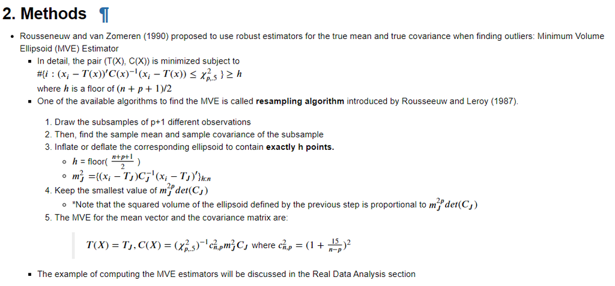

- For the regression problem, the authors proposed to use a high-breakdown regression estimators,  
  and as an example, the author briefly provided the least median estimator:
  - minimize$_{\theta}$ median$_{i = 1, 2, ... , n }$ $r^2_i (\hat{\theta})$

# 3. Results

### **1. Finding outliers from a sample from a multivariate normal distribution**

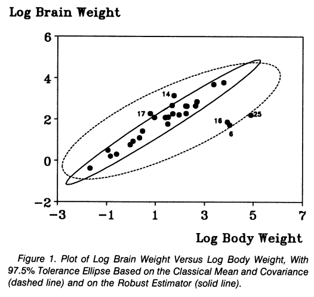

### **2. Finding outliers and leverage points**

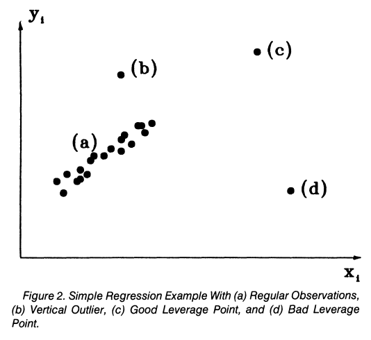

# 4. Discussion

### **1. Finding outliers from a sample from a multivariate normal distribution**

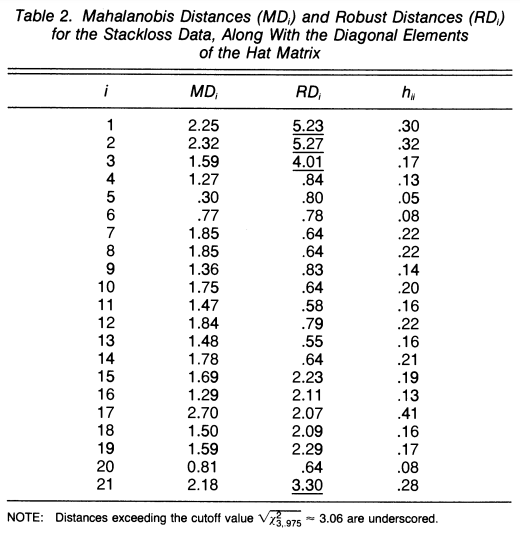

### **2. Finding outliers and leverage points in regression**

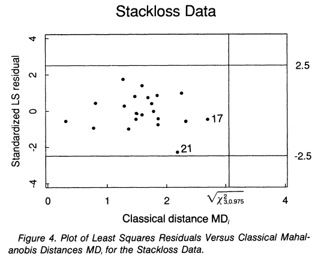

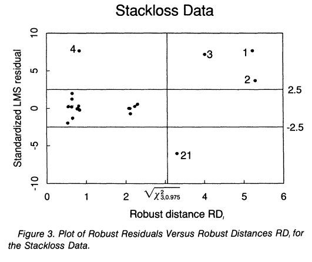

# 5. Real Data Analysis

# Data Description

## Part I. Table 7.6$^{[1]}$

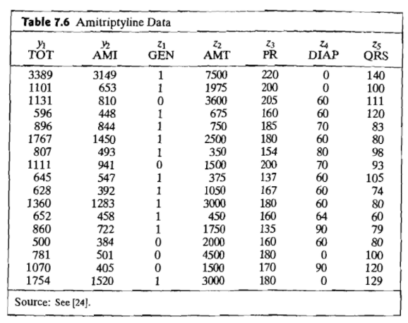

Y1 : Total TCAD Plasma level  
Y2 : Amount of amitriptyline present in TCAD plasma level (AMI)  
Z1 : Gender (0: Male, 1: Female) Z2 : Amount of antidepressants taken at time of overdose  
Z3 : PR wave measurement  
Z4 : Diastolic blood pressure  
Z5 : QRS wave measurement

[figure not shown]

#### However, (z1, ..., z5) is multivariate normal???

#### Let's try this with multivariate normal sample

## Part II: Random Multivariate Normal Samples

## When the sample size is small and the number of outliers is relatively large

[figure not shown]

## When we have a large sample size and a small size of outliers relative to the sample size

[figure not shown]

## Scatter Plot and the Confidence Ellipse

[figure not shown]

# 6. Conclusion:

- First thing to make sure before using the method is whether the sample is approximately multivariate normal
- When we had many outliers compared to the sample size, this robust measure detects outliers better than the classic method.
- When the sample size is large and we have a small amount of outliers relative to the sample, you will see the similar results.

# References

1. Applied Multivariate Statistical Analysis (6th ed.) R. A. Johnson & D. W. Wichern, Prentice Hall, 2008.
2. Peter J Rousseeuw and Bert C Van Zomeren. Unmasking multivariate outliers and leverage points.Journal of the American Statistical association, 85(411):633–639, 1990.